```python
import numpy as np, matplotlib.pyplot as plt, librosa as lr
```

# DFT (Diskrete Fourier Transformation)

## Stichwort 'Transformation'

Das Wort 'Transformation' in DFT ist tatsächlich wörtlich zu nehmen. Wir gehen von einem Signal $x_n$ aus und transformieren es: $$x_n \rightarrow X_k$$

Das resultierende Signal $X_k$ ist wiederum eine Zahlenfolge, die aber nicht von $n$ (unserem zeitlichen Index) indiziert wird, sondern vom Index $k$, ein Index für die Frequenzen, auf welche in der DFT getestet wird.

## Formel

$${\displaystyle \sum_{n=0}^{N - 1}{x_n \cdot e^{- 2 \pi i k \cdot \frac{n}{N}}}}$$

- $n$: Sample-Index
- $N$: Anzahl der Samples im Audio-Signal
- $x_n$: Audio-Signal
- $k$: Frequenz-Index $\{ X_k \}: X_0, X_1, \dots, X_{N - 1}$

Diese Formel ist im Kern das Ähnlichkeitsmaß, welches wir zuvor kennengelernt haben. Unsere Art der Berechnung in der Winding-Machine ist auch sehr ähnlich (siehe aehnlichkeitsmass-winding-machine).

## Implementierung

```python
def calc_dft(x):

    N = x.size
    n = np.arange(N)
    dft = np.zeros(N, dtype=complex)

    for k in range(N):
        dft[k] = np.sum(x * np.exp(-2 * np.pi * 1j * k * n / N))

    return dft
```

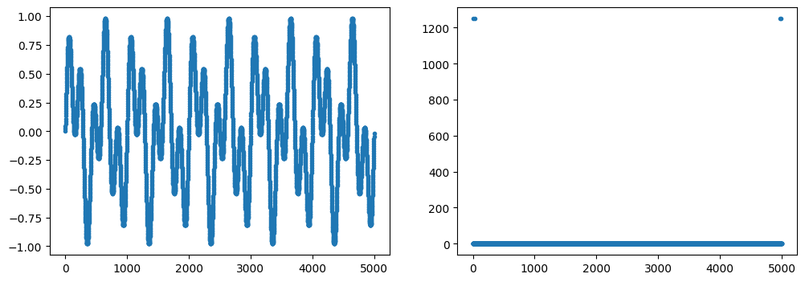

```python
length = 5 # sec
freq1, freq2 = 2, 5 # Hz
sr = 1000 # Hz

N = int(sr * length)
n = np.arange(N)
# Signal generieren (additiv)
x = (np.sin(2 * np.pi * n / sr * freq1) * 0.5)\
  + (np.sin(2 * np.pi * n / sr * freq2) * 0.5)

dft = calc_dft(x)

# plot:
plt.figure(figsize=(12, 4))

plt.subplot(1, 2, 1)
plt.plot(x, '.')

plt.subplot(1, 2, 2)
plt.plot(np.abs(dft), '.')

plt.show()
```

Auf der linken Seite plotten wir das Signal (bestehend aus zwei Sinustönen mit den Frequenzen 2 und 5 Hz) – rechts die DFT.

**Beobachtung**:

- Der DFT-Plot scheint symmetrisch zu sein.
- Fast alle Werte sind gleich 0.
- Sehr weit am Anfang und Ende der DFT sehen wir hohe Ausschläge. Es sieht fast symmetrisch aus.

## Eigenschaften der DFT

Wir plotten nun einen kleineren Ausschnitt der DFT für niedrige $k$-Werte (also auf der linken Seite):

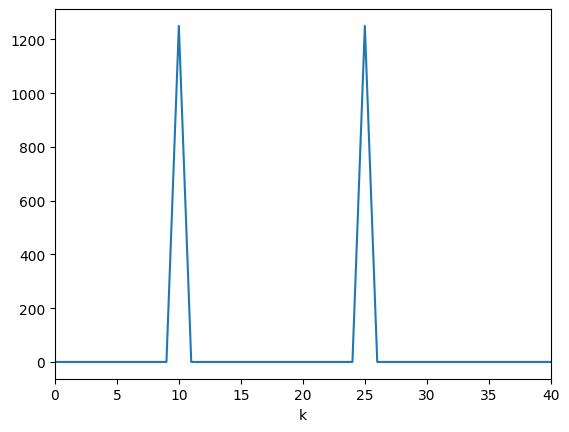

```python
plt.plot(np.abs(dft))
plt.xlim(0, 40) # Bereich ausprobiert
plt.xlabel('k')
plt.show()
```

Dieses Ergebnis sollten wir auch erwarten, da wir ja wissen, dass sich in unserem Signal 2 Frequenzen im niedrigen Bereich befinden.

Und jetzt die letzten Werte für $k$:

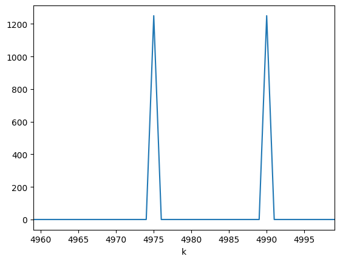

```python
plt.plot(np.abs(dft))
plt.xlim(N - 41, N - 1)
plt.xlabel('k')
plt.show()
```

Es bestätigt sich also unsere Vermutung der Symmetrie!

Die Ausschläge im hohen $k$ Bereich sind die gespiegelten Frequenzen des Signals an der Nyquist-Grenze.

Wenn wir also nochmals den gesamten Bereich plotten, befindet sich die Nyquist-Grenze also in der Mitte:

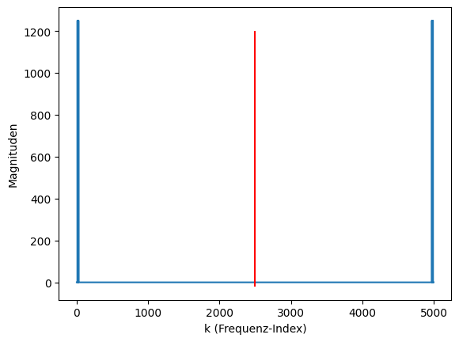

```python
plt.plot(np.abs(dft))
plt.vlines(2500, -20, 1200, color=[1, 0, 0, 1])
plt.xlabel('k (Frequenz-Index)')
plt.ylabel('Magnituden')
plt.show()
```

## Berechnung der Frequenzen in Hz zu einem gegebenen $k$

Folgende Formel können wir verwenden, um zu berechnen, welche Frequenzen in Hz tatsächlich den Indizes $k$ entsprechen: $$f = \dfrac{k \cdot sr}{N}$$

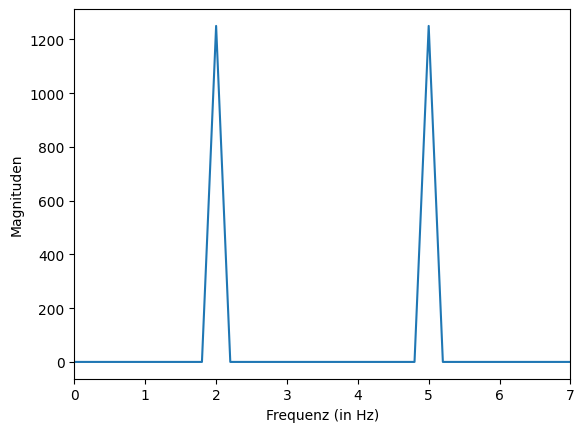

```python
k = np.arange(N)

f = k * sr / N

plt.plot(f, np.abs(dft))
plt.xlim(0, 7)
plt.xlabel('Frequenz (in Hz)')
plt.ylabel('Magnituden')
plt.show()
```

Im obigen Plot haben wir die berechneten Frequenzen in Hz direkt im Plot angezeigt. Jetzt können wir auch gut ablesen, dass die gemessenen Frequenzen auch denjenigen entsprechen, die im Signal tatsächlich vorhanden sind.

## Weitere Experimente

```python
def plot_signal_dft(x, dft, sr, f_limit=7):

    plt.figure(figsize=(12, 4))

    N = x.size
    n = np.arange(N)
    k = np.arange(N)
    f = k * sr / N

    plt.subplot(1, 2, 1)
    plt.plot(n / sr, x)
    plt.xlabel('Zeit (t)')

    plt.subplot(1, 2, 2)
    plt.plot(f, np.abs(dft))
    plt.xlim(0, f_limit)
    plt.xlabel('Frequenz (in Hz)')
    plt.ylabel('Magnituden')

    plt.show()
```

### Unterschiedliche Amplituden-Gewichtungen im Audio-Signal

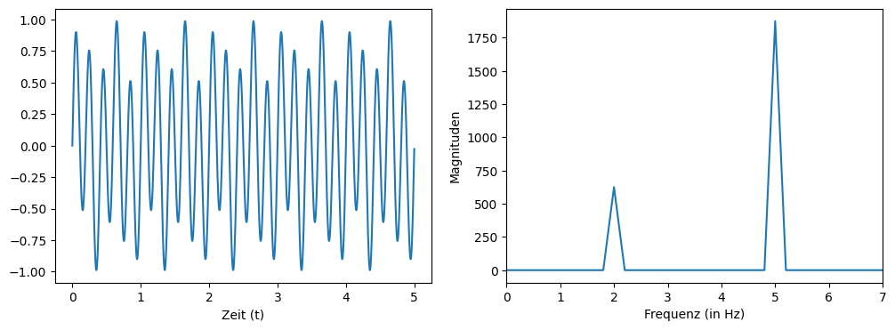

```python
length = 5 # sec
freq1, freq2 = 2, 5 # Hz
sr = 1000 # Hz

N = int(sr * length)
n = np.arange(N)
x = (np.sin(2 * np.pi * n / sr * freq1) * 0.25)\
  + (np.sin(2 * np.pi * n / sr * freq2) * 0.75)

dft = calc_dft(x)

plot_signal_dft(x, dft, sr)
```

### 2 Frequenzen hintereinander

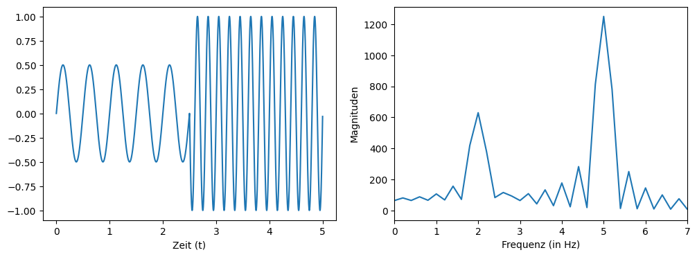

```python
length = 5 # sec
freq1, freq2 = 2, 5 # Hz
sr = 1000 # Hz

N = int(sr * length)
n = np.arange(N)
N_half = int(N // 2)
x = np.concatenate([(np.sin(2 * np.pi * n[:N_half] / sr * freq1) * 0.5),
                    (np.sin(2 * np.pi * n[N_half:] / sr * freq2) * 1)])

dft = calc_dft(x)

plot_signal_dft(x, dft, sr)
```

### 2 Frequenzen hintereinander mit unterschiedlicher Länge

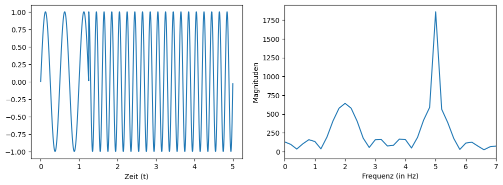

```python
length = 5 # sec
freq1, freq2 = 2, 5 # Hz
sr = 1000 # Hz

N = int(sr * length)
n = np.arange(N)
N_quarter = int(N // 4)
x = np.concatenate([(np.sin(2 * np.pi * n[:N_quarter] / sr * freq1) * 1),
                    (np.sin(2 * np.pi * n[N_quarter:] / sr * freq2) * 1)])

dft = calc_dft(x)

plot_signal_dft(x, dft, sr)
```

### Analyse (DFT) eines Audio-Signals "aus der echten Welt"

```python
!curl https://cdn.freesound.org/previews/355/355908_6552981-lq.mp3 -o violin.mp3
```

```
  % Total    % Received % Xferd  Average Speed   Time    Time     Time  Current
                                 Dload  Upload   Total   Spent    Left  Speed
100 39480  100 39480    0     0   176k      0 --:--:-- --:--:-- --:--:--  179k
```

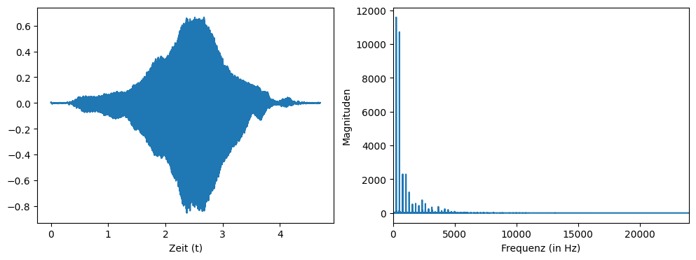

```python
x, sr = lr.load('violin.mp3', sr=None)
dft = np.fft.fft(x)
# dft = calc_dft(x) # die Berechnung mit unserer DFT-Funktion würde sehr lange dauern

plt.figure(figsize=(12, 4))

N = x.size
k = np.arange(N)
f = k * sr / N

plot_signal_dft(x, dft, sr, f_limit=int(sr // 2))
```